# User Guide

### Overview

vShell is a virtual shell environment application for the Android OS. It provides a virtual machine running small Linux distribution ready for the use out-of-box.

Here are some details on the virtual machine configuration:

- CPU: emulated 1-core x86 64-bit.
- RAM: up to 2 GiB, depending on available **free** host memory.
- HDD: 64 GB, has a default 4 GB partition for user data.
- Host storage: via 9P FS, mount tag `host_storage`.
- Network: user-mode via SLiRP.
- Operating system: [Alpine Linux](https://alpinelinux.org/).

Please note that provided default setup of the Alpine Linux is diskless. The whole operating system is copied into RAM, which takes about 80 MB. All changes are discarded unless were saved to the disk with the utility [lbu](https://wiki.alpinelinux.org/wiki/Alpine_local_backup). In order to change this behavior, you will need to format HDD and re-install the system from scratch, which could be easily done via ‘setup-alpine’ utility.

**Disclaimer**: neither vShell application nor its author is affiliated with the [Alpine Linux](https://alpinelinux.org/) project. Operating system is provided as-is and vShell author is not responsible about bugs in the software packages.

*This guide does not cover Shell Scripting and Linux System Administration topics.*

### User interface

#### Terminal

vShell application uses the XTerm-compatible terminal emulator as a frontend for a serial console of the virtual machine. It has a True Color support and uses Inconsolata LGC font patched by Nerd-Fonts for additional glyphs support.

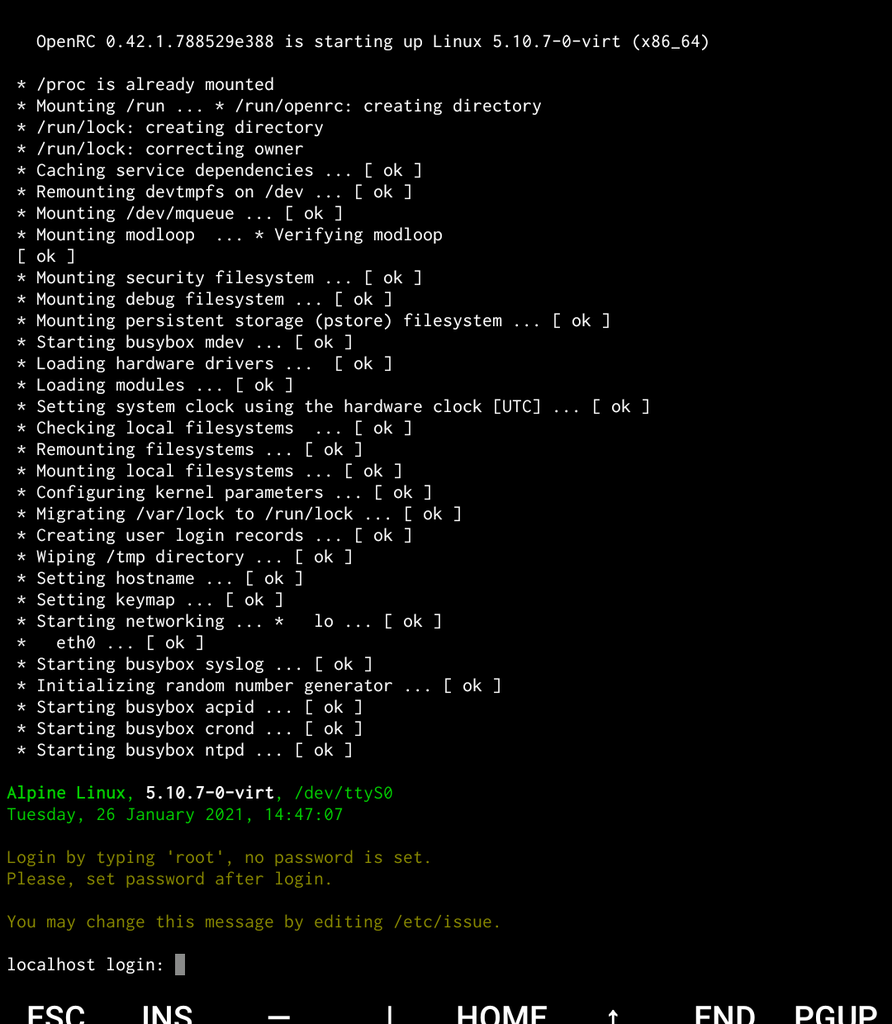

The application does not provide a way for customizing the terminal style like a color scheme or the font, because chosen defaults are considered as suitable for the most configurations.

The terminal reacts to the following kinds of a user input:

- A pinch-zooming gesture to scale the text size.
- A long tap to start text selection or open a context menu.
- A single tap to emulate a mouse left button click.

Please note that this application is intended to have only one terminal session by design. To have more, you will need to use a terminal multiplexer like `tmux`.

##### Troubleshooting: terminal has stuck

The terminal is sensitive to printed data. If a binary content has been accidentally printed or some misbehaving program incorrectly initialized the console, it can be easily messed up.

In this case, you need to either execute the command `reset` or tap a button **Reset** which is located in the context menu.

##### Troubleshooting: misplaced text

If you have re-scaled the text size, you may observe an incorrect line wrapping or misplaced UI elements of the console applications. That is happening due to the nature of the serial line, which does not support a screen size handshaking.

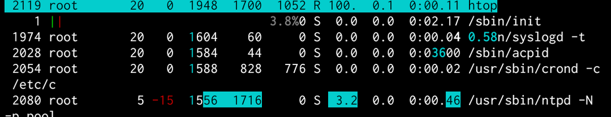

To solve the issue, you need to use a command `resize` after changing the text scale. A default setup of the operating system provided by vShell application runs this command automatically in a preexec hook of Zsh shell.

#### Notification

When the application has successfully started a foreground service, a notification will be shown. Clicking on the notification will open the terminal session. Expanding the notification would reveal some action buttons.

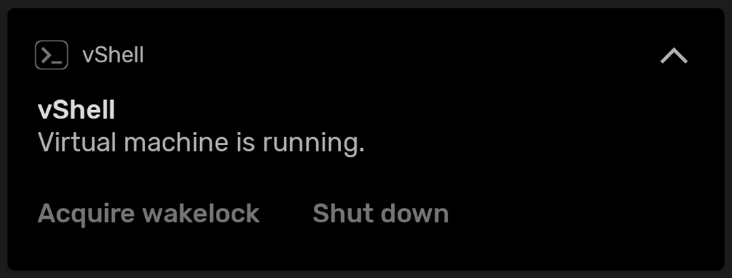

Clicking on a button **Acquire wakelock** will prevent the device from going into the sleep mode. Use this action when you need to keep the virtual machine from being suspended when the screen is turned off.

**Tip:** enable wake lock to avoid VM time shifting issues when your device screen is off.

Clicking on a button **Shut down** will immediately close the application. Shutting down the virtual machine by this way can lead to a loss of unsaved data, so be careful.

#### Keyboard

##### Touch keyboard shortcuts

**Volume Down** key emulates the **Ctrl** key which can be combined with others to request a special action. The possible key combinations are the software-specific. To learn about them, consult with a documentation of your installed packages.

**Volume Up** key produces a certain input in the following combinations:

| Key combination | Produced input |
| --- | --- |
| `Volume-Up .` | `Ctrl \` |
| `Volume-Up <1..9>` | `F1`, `F2`, …, `F9` keys |
| `Volume-Up 0` | `F10` |
| `Volume-Up A` | Left arrow key |
| `Volume-Up B` | `Alt B` |
| `Volume-Up D` | Right arrow key |
| `Volume-Up E` | Escape |
| `Volume-Up F` | `Alt F` |
| `Volume-Up H` | `~`, the tilde character |
| `Volume-Up K` | Toggle extra keys row |
| `Volume-Up L` | `\|`, the pipe character |
| `Volume-Up N` | Page down key |
| `Volume-Up P` | Page up key |
| `Volume-Up S` | Down arrow key |
| `Volume-Up T` | Tab key |
| `Volume-Up U` | `_`, the underscore character |
| `Volume-Up V` | Show the volume control |
| `Volume-Up W` | Up arrow key |
| `Volume-Up X` | `Alt X` |

Note that **Volume Up** does not represent the **Alt** key even though it is being used to emulate certain its combinations.

##### Hardware keyboard shortcuts

These key combinations can be used on a hardware keyboard to trigger certain actions of the application:

| Key combination | Action |
| --- | --- |
| `Ctrl Alt +` | Increase text size |
| `Ctrl Alt -` | Reduce text size |
| `Ctrl Alt K` | Toggle the touch keyboard |
| `Ctrl Alt M` | Open context menu |
| `Ctrl Alt U` | Open URL selector |
| `Ctrl Alt V` | Paste clipboard |

##### Extra Keys Row

Extra Keys Row is a widget displayed above the touch keyboard. It provides special keys that are commonly used by console programs.

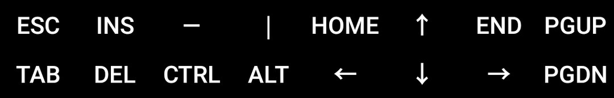

Swiping up some keys will expose the alternate ones. Particularly:

- `-` will show a key for `_`
- `|` will show a key for `&`

You may toggle the Extra Keys Row with a key combination **Volume Up+K**.

### Port forwarding

QEMU is configured to expose the guest ports 22 and 80 as the random ports on host system. These ports are exposed externally, i.e. to Wi-Fi LAN or mobile network, the latter however is likely firewalled. While the primary purpose of these ports is for accessing SSH and Web servers, you can assign any custom services to guest 22 or 80 ports respectively.

The application context menu provides information about ports as well as shortcuts for opening either SSH client (e.g. ConnectBot) or Web browser.

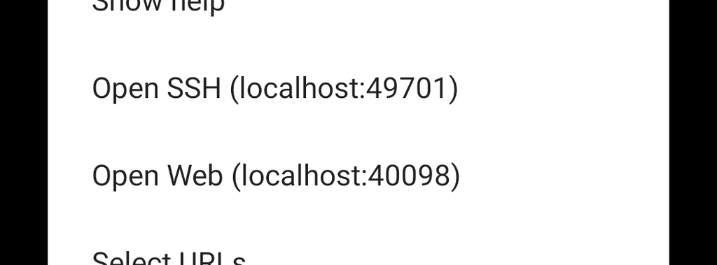

vShell comes without any server software installed. You have to install and configure it on your own. Just remember that it should listen on TCP port 22 or 80.

*vShell — a virtual shell environment application.*